# graph_analysis

inryeol

2024-08-05

```r
rm(list=ls())
```

# 변수 가져오기

1. 변수 이름 : pollution
2. 변수들의 타입 지정하기 (순서대로)
   - numeric, character, factor, numeric, numeric

   ```r
   class = c("numeric", "character", "factor", "numeric", "numeric")
   pollution = read.csv("../../dataset/avgpm25.csv", colClasses = class)
   ```

> 이후 구조를 확인한다.

```r
head(pollution)
```

```
##        pm25  fips region longitude latitude
## 1  9.771185 01003   east -87.74826 30.59278
## 2  9.993817 01027   east -85.84286 33.26581
## 3 10.688618 01033   east -87.72596 34.73148
## 4 11.337424 01049   east -85.79892 34.45913
## 5 12.119764 01055   east -86.03212 34.01860
## 6 10.827805 01069   east -85.35039 31.18973
```

```r
str(pollution)
```

```
## 'data.frame':    576 obs. of  5 variables:
##  $ pm25     : num  9.77 9.99 10.69 11.34 12.12 ...
##  $ fips     : chr  "01003" "01027" "01033" "01049" ...
##  $ region   : Factor w/ 2 levels "east","west": 1 1 1 1 1 1 1 1 1 1 ...
##  $ longitude: num  -87.7 -85.8 -87.7 -85.8 -86 ...
##  $ latitude : num  30.6 33.3 34.7 34.5 34 ...
```

# 1차원 그래프

## 요약통계량

```r
summary(pollution$pm25)
```

```
##    Min. 1st Qu.  Median    Mean 3rd Qu.    Max.
##   3.383   8.549  10.047   9.836  11.356  18.441
```

결과

## boxplot

> pollution 중 pm25의 Boxplot을 보자.

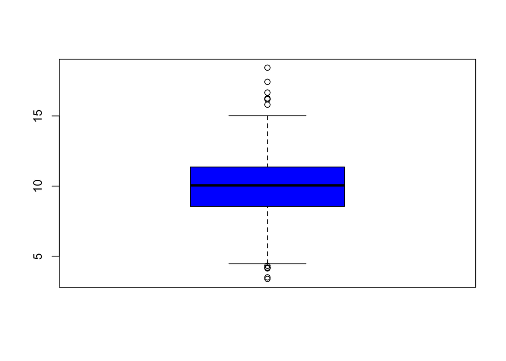

```r
boxplot(pollution$pm25, col="blue")
```

> pm25가 15보다 큰 케이스를 살펴보자.

```r
# no.1
with(pollution, head(pm25[pm25 > 15]))
```

```
## [1] 16.19452 15.80378 18.44073 16.66180 15.01573 17.42905
```

```r
# no.2
subset(pollution, pm25 > 15)
```

```
##        pm25  fips region longitude latitude
## 46 16.19452 06019   west -119.9035 36.63837
## 50 15.80378 06029   west -118.6833 35.29602
## 51 18.44073 06031   west -119.8113 36.15514
## 53 16.66180 06037   west -118.2342 34.08851
## 55 15.01573 06047   west -120.6741 37.24578
## 61 17.42905 06065   west -116.8036 33.78331
## 76 16.25190 06099   west -120.9588 37.61380
## 78 16.18358 06107   west -119.1661 36.23465
```

```r
# no.3
head(pollution[pollution$pm25 > 15,], 8)
```

```
##        pm25  fips region longitude latitude
## 46 16.19452 06019   west -119.9035 36.63837
## 50 15.80378 06029   west -118.6833 35.29602
## 51 18.44073 06031   west -119.8113 36.15514
## 53 16.66180 06037   west -118.2342 34.08851
## 55 15.01573 06047   west -120.6741 37.24578
## 61 17.42905 06065   west -116.8036 33.78331
## 76 16.25190 06099   west -120.9588 37.61380
## 78 16.18358 06107   west -119.1661 36.23465
```

- 지역은 전부 서부라고 나온다.
- west이면서 fips 코드 앞자리가 06인 곳 : 캘리포니아

## Histogram

pm25의 히스토그램을 한번 보자.

breaks=100으로 해서 잘게 짜르고, 밀집도를 볼 수 있게 한다.

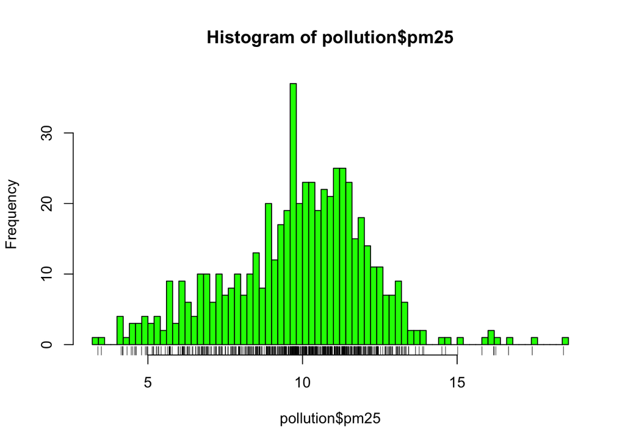

```r
# hist of PM2.5
hist(pollution$pm25, col="green", breaks=100)
rug(pollution$pm25)
```

## 저수준 그래픽

그래프 위에 무언가를 씌울 때 사용한다.

주로 선을 그려 중위수나 기준을 표기한다.

### 예시 1

pm25의 histogram. 기준선1을 10에, 기준선2를 12에 그려준다.

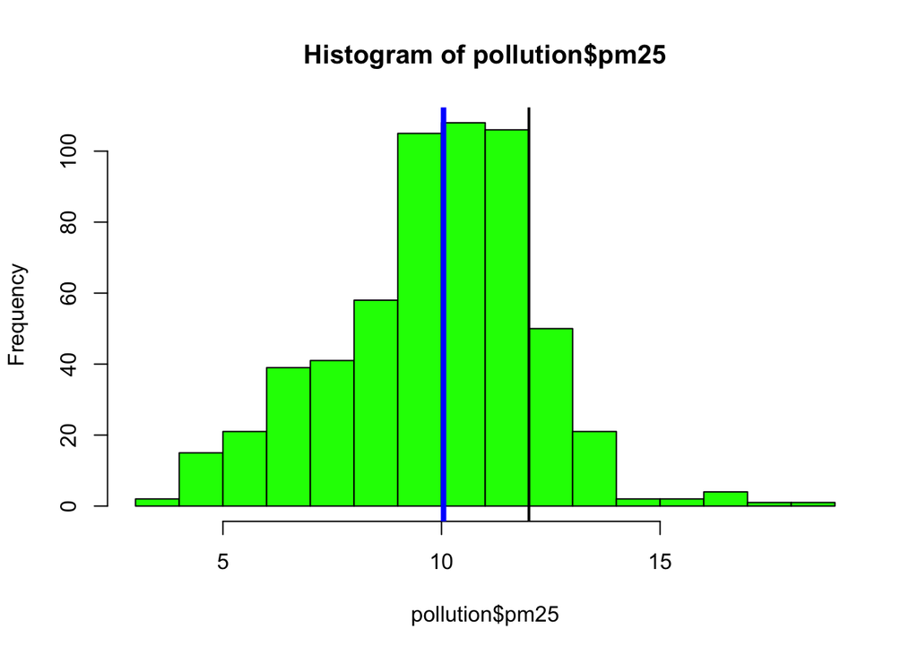

```r
# hist of PM2.5
hist(pollution$pm25, col="green")
abline(v = 12, lwd=2) # 기준치
abline(v = median(pollution$pm25), col="blue", lwd=4) #
```

### 예시 2

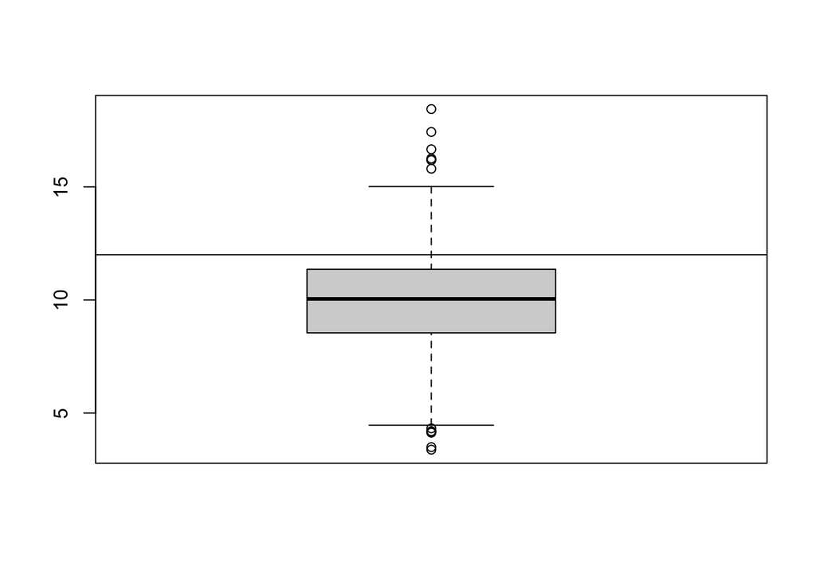

```r
# boxplot + abline of pm25
boxplot(pollution$pm25)
abline(h = 12) # 기준치
```

## Barplot

범주형 자료(categorical data)를 정리할 때 좋다.

먼저 table을 써서 정리를 한 다음, barplot을 그려준다.

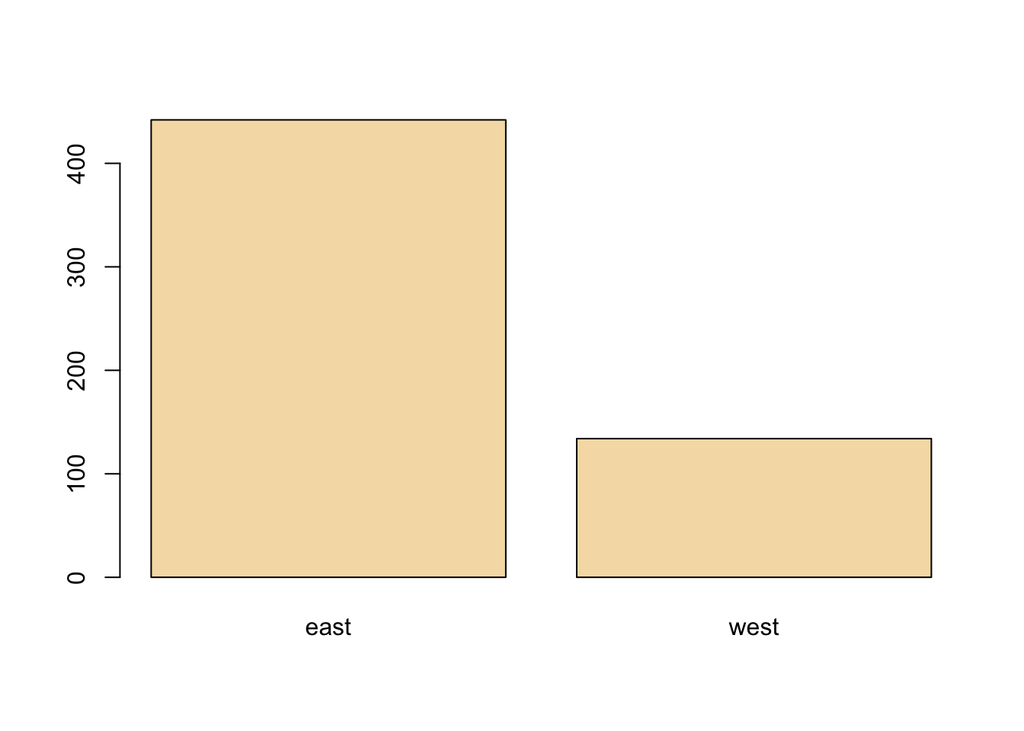

```r
barplot(table(pollution$region), col="wheat")
```

**west와 east의 순서를 바꾸고 싶다면?**

- factor를 다시 지정해야 한다.

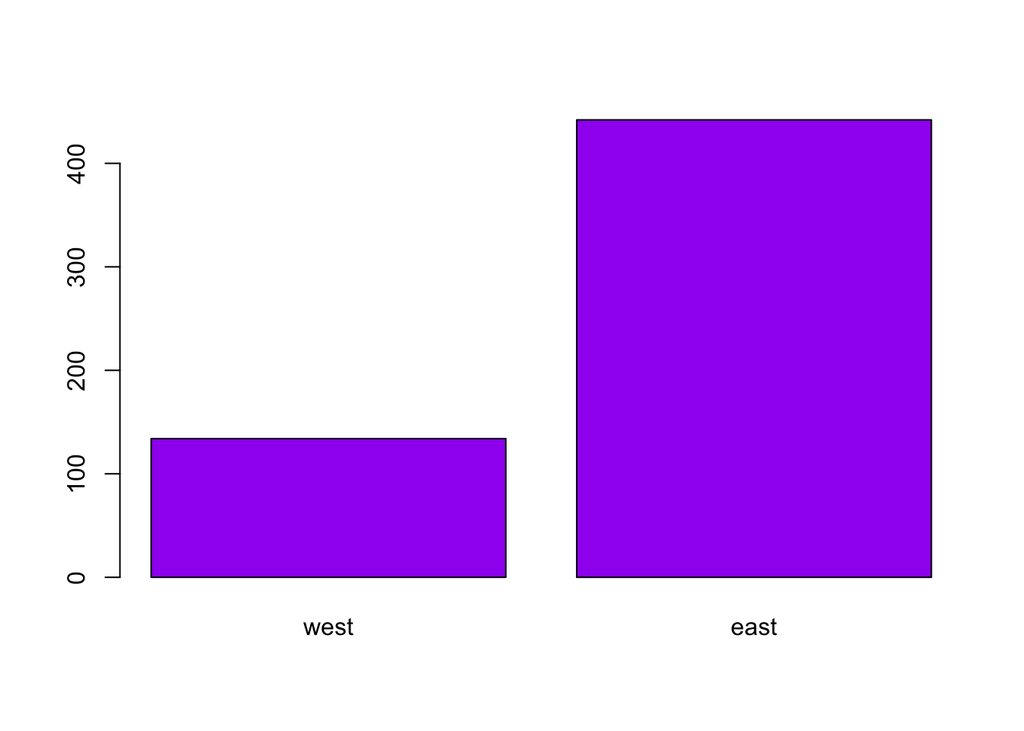

```r
pollution$region = factor(pollution$region, levels = c("west", "east"))
barplot(table(pollution$region), col="purple")
```

# 2차원 그래픽

## 다차원 boxplot

> 지역별 pm2.5을 도출해보자.

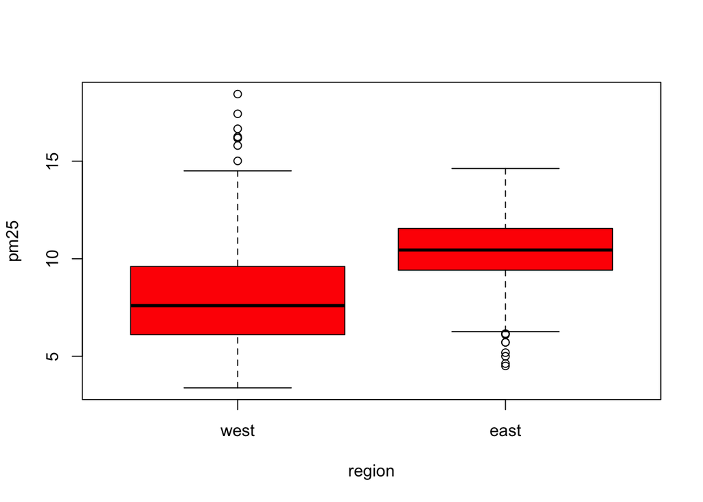

```r
boxplot(pm25~region, data = pollution, col="red")
```

## 다차원 histogram

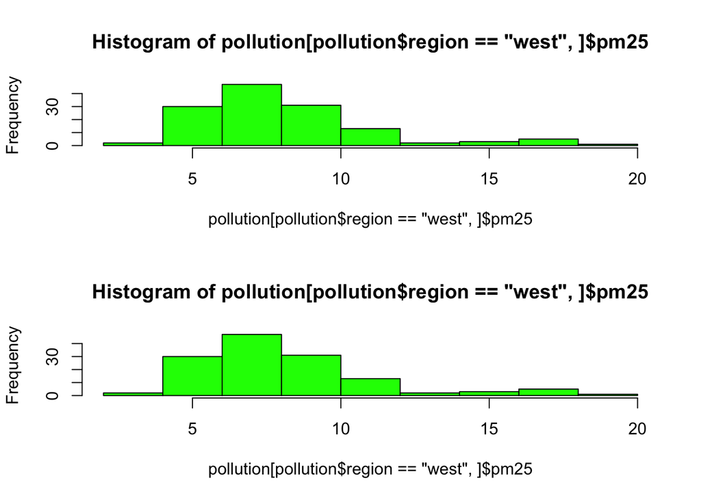

```r
par(mfrow=c(2,1))
hist(pollution[pollution$region == "west",]$pm25,
     col="green")
hist(pollution[pollution$region == "west",]$pm25,
     col="green")
```

## Scatterplot

> latitude에 따른 pm2.5를 구해보자.

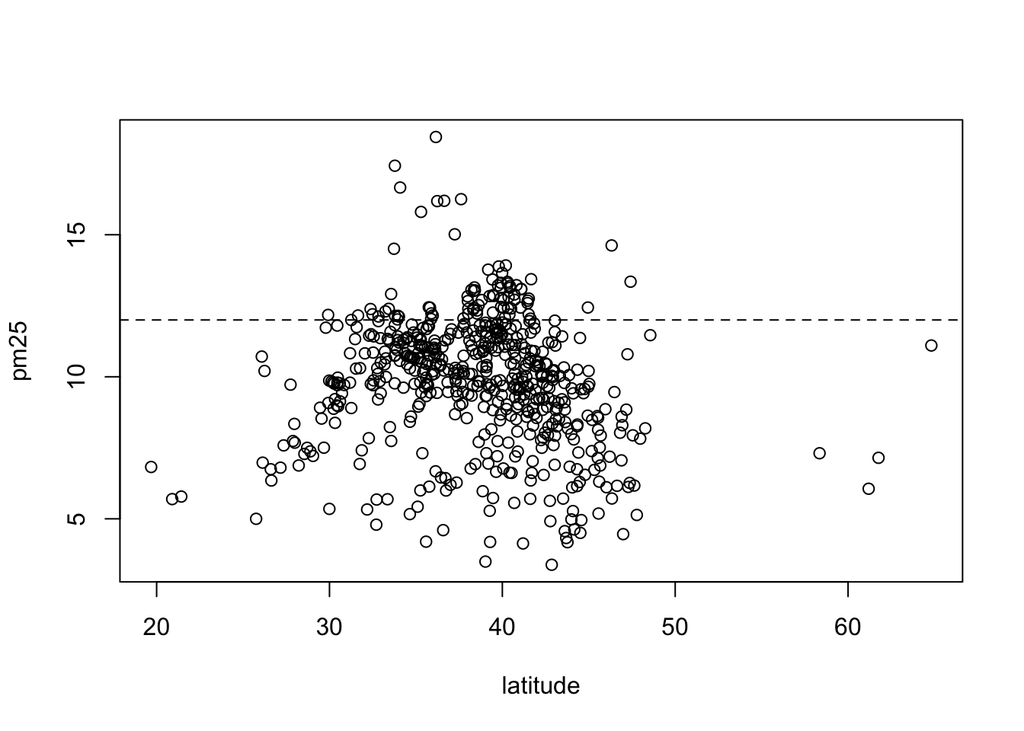

```r
plot(pollution$pm25~pollution$latitude,
     xlab="latitude", ylab="pm25")
abline(h=12, lty=2)
```

> **latitude에 따른 pm2.5. 색으로 region 구분해주기**

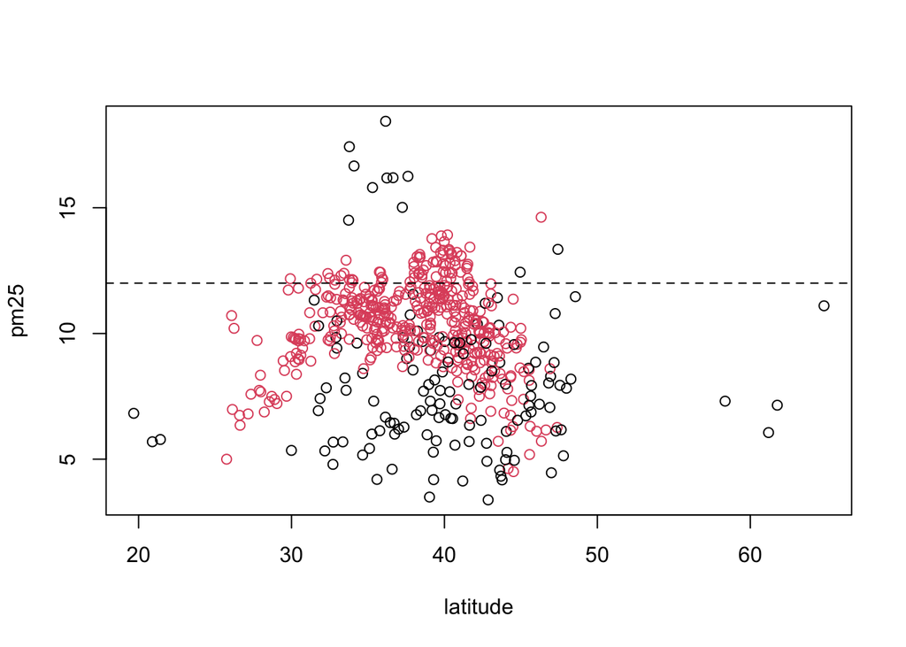

```r
plot(pollution$pm25~pollution$latitude,
     xlab="latitude", ylab="pm25",
     col=pollution$region)
abline(h=12, lty=2)
```

> 지역에 따른 구분. latitude별 pm25

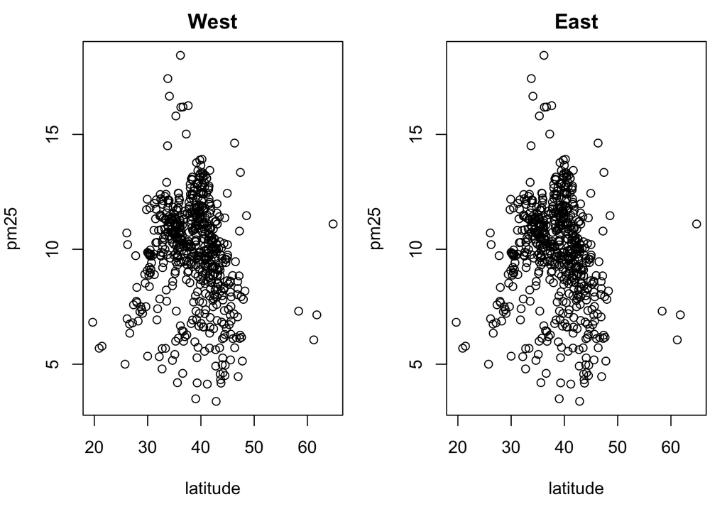

```r
par(mfrow=c(1,2), mar=c(5, 4, 2, 1))
with(subset(pollution, region == "West"),
     plot(pollution$pm25~pollution$latitude,
          main="West", ylab="pm25",
          xlab="latitude"))
with(subset(pollution, region == "East"),
     plot(pollution$pm25~pollution$latitude,
          main="East", ylab="pm25",
          xlab="latitude"))
```

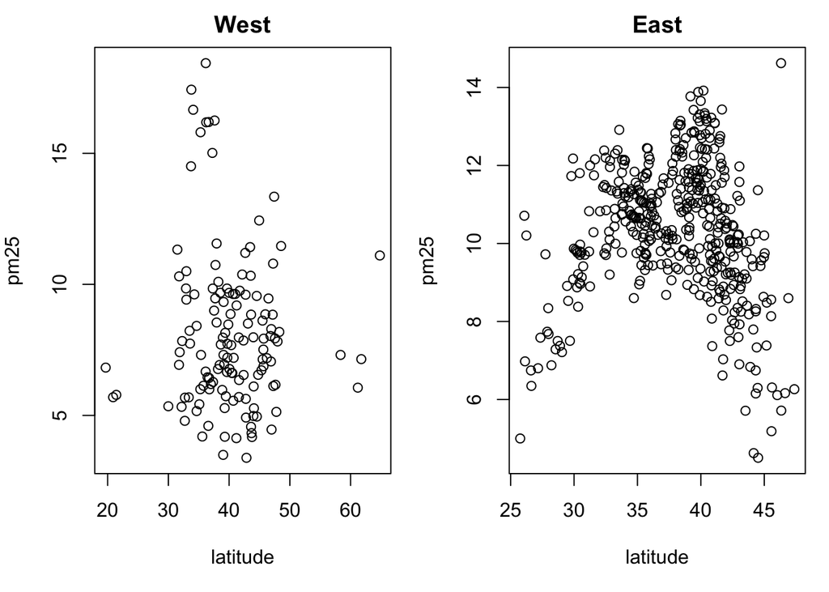

```r
par(mfrow=c(1,2), mar=c(5, 4, 2, 1))
plot(pm25~latitude,data=pollution[pollution$region=="west",],main="West")
plot(pm25~latitude,data=pollution[pollution$region=="east",],main="East")
```

**tip : 여백을 지정할때 mar()을 사용한다.**

# 그래픽용 도구

여러 창을 한번에 띄울때는 다음과 같은 함수를 사용한다.

- `quartz()` : 맥에서 사용
- `windows()` : 윈도우에서 사용
- `x11()` : 리눅스에서 사용

또한 pdf로 저장할 때는 다음과 같은 절차를 따른다.

1. `pdf()` 함수로 열어준다.
2. 그래프를 편집한다.
3. `dev.off()`로 닫아준다. (닫아야 그래프 편집내용이 저장.)